# WOMBAT 2026 Tutorial

Publishing your software

Dianne Cook, Fonti Kar

Department of Econometrics and Business Statistics

## Welcome 👋🏼

Thanks for joining to

🦘 **[Di](https://www.dicook.org)** is a *Professor of Statistics*. She has more than 30 years of research and teaching of data visualisation, and open-source software development. She has published more than 10 papers on software.  
🐨 **[Fonti](https://fontikar.github.io)** is a *lecturer in Data Analytics and Statistics*. She has a background in evolutionary ecology, biology and open-source tool building, and is passionate in the learning new skills in R/Quarto and sharing it with others.

*We are both in Econometrics and Business Statistics, at Monash University.*

🧩 Feel free to ask questions any time. 🤔

🎯 The objectives for today are to:

- be able list several outlets available for publishing software
- understand the benefits of publishing a software paper
- identify the components of a well-constructed software article
- draft an paper on your own software

# Outline

**Session 1: Where, why, how**

- Why publish software as an article?
- Value of software papers in academic careers (citations, recognition, tenure/promotion)
- Benefits for the community (visibility, credibility, discoverability).
- Why is a paper better than supplementary material for a regular paper?
- Common outlets for publishing software:
- How are the articles in different outlets structured?
- Your turn: Compare articles
- What goes into an article about software?
- Problem statement and motivation
- Putting your work in the context of existing software
- Key features of the software
- Design/implementation details
- Overview of workflow
- Examples/use cases/applications/speed comparisons/benchmarking
- Your turn: Outline own article

**Session 2: Prepare to write your article**

- Putting your work in the context of others
- Your turn: Lit review
- Guide your reader with a conceptual diagram
- Your turn: Make a sketch
- Is your software ready?
- Your turn: Review checklist for your software
- Publishing best practices
  - Handling big data, or private data
  - Handling slow computation/reproducibility
  - Tips for figures
  - Reproducibility of your article
- Last details
  - Writing a cover letter
  - Submission instructions
- Your turn: Write a cover letter

# Session 1

# Why publish software as an article?

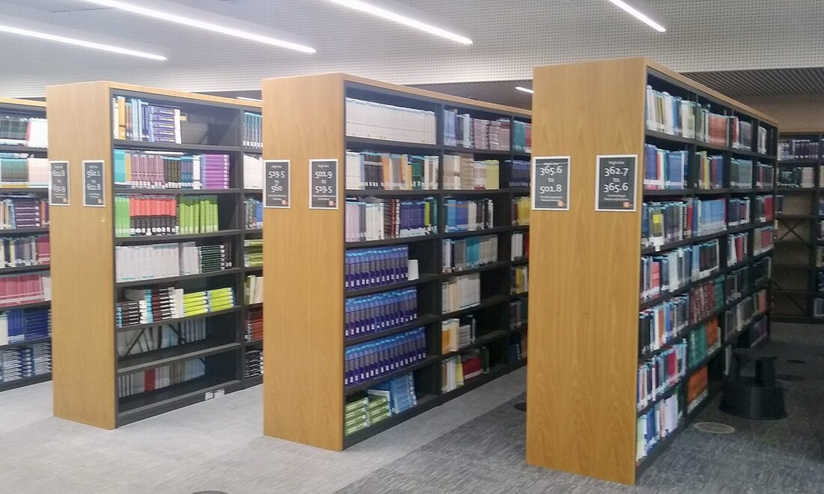

Photo: [Mertbiol](https://commons.wikimedia.org/wiki/File:Books_on_library_shelves,_Davison_Building,_Royal_Holloway_University_of_London,_Surrey_-_September_2026_-_01.jpg), [CC0](https://creativecommons.org/publicdomain/zero/1.0/), via Wikimedia Commons

## What is a software article?

It is an academic publication whose primary subject is a piece of software. Instead of reporting a scientific finding, the paper typically describes:

- **What the software does**: the problem it solves and how it fits into the existing landscape of tools.
- **How it works**: the underlying methods, algorithms, or statistical models it implements.
- **How to use it**: installation, basic API/interface, and often a worked example or application.
- **Why it matters**: the gap it fills, who the intended users are, and how it differs from alternatives.
- **Availability**: where the code lives (e.g., CRAN, GitHub), license, and how to cite it.

**Software**

GitHub / CRAN

↓

**Software article**

indexed, peer reviewed, DOI

↓

**Users find, trust and cite your software**

## Benefits to the community

1. **Discoverability**

A GitHub repo or CRAN listing is easy to miss unless someone already knows to look for it. A paper in an indexed journal (Web of Science, Scopus, Google Scholar) surfaces the tool to people searching the literature by topic or method, not by package name.

2. **Peer-reviewed vetting of methodology**

Code review (via CRAN checks or GitHub CI) verifies the software runs. It doesn’t verify that the statistical or computational methods behind it are sound. Peer review of a software paper adds a layer of scrutiny on the actual science.

3. **Structured comparison to alternatives**

Because papers are expected to situate the tool relative to existing options, they often produce the clearest available account of the landscape of similar tools.

4. **Faster adoption and trust**

A peer-reviewed paper signals a baseline of quality and rigor to potential users who are deciding whether to build their analysis pipeline around a new tool.

5. **Documentation that outlives the maintainer**

Vignettes and READMEs get out of date or vanish if a repo is abandoned. A published paper is archived independently (by the journal, DOI, sometimes in institutional repositories) and remains a stable description of the tool’s design and rationale even if the software itself evolves or stops being maintained.

## Why not publish just as supplementary material?

A standalone software paper is discoverable and citable in ways supplementary material isn’t: search engines and citation databases index main articles, not S1 files, so a tool described only as a supplement to an unrelated study is nearly invisible to someone searching for a general-purpose method, and there’s no clean way to cite it without citing the whole host paper. Supplementary material also gets far less rigorous review, while a dedicated paper subjects the software to real scrutiny and gives it proper room for design rationale, comparisons, and examples. It decouples the tool from any one study’s lifecycle, framing it as reusable infrastructure that can be updated over time, and it converts the effort of building it into a distinct, indexed scholarly output, which matters for the career incentives of whoever’s real contribution was the software itself.

## Common outlets

- Outlets
- Comparison
- [Journal of Statistical Software](https://www.jstatsoft.org/index)
- [The R Journal](https://journal.r-project.org)
- [Journal of Open Source Software](https://joss.theoj.org)

Many domain-specific journals have a software section, for example:

- [Genome Biology](https://link.springer.com/journal/13059/volumes-and-issues/27-1)
- [Methods of Ecology and Evolution](https://besjournals.onlinelibrary.wiley.com/toc/2041210x/current)
- [Royal Society Open Science](https://royalsocietypublishing.org/rsos)
- [Applications in Plant Sciences](https://bsapubs.onlinelibrary.wiley.com/journal/21680450)

| Criterion | JSS | The R Journal | JOSS |
| --- | --- | --- | --- |
| Scope | Any statistical software | R only | Any research software |
| Length | Long (full paper) | Medium-long | Very short |
| Review focus | Methodology + code | Package quality + writeup | Codebase (tests, docs, license) |
| Output format | PDF only | Native HTML (+ PDF) | PDF (via Markdown/GitHub) |
| Interactive figures | Not supported | Supported (native HTML) | Not part of the paper itself |
| Impact factor | High | Moderate, variable | None by design |
| Time to publish | Slower, thorough | Moderate | Often fast if code is ready |
| Best fit | Novel/complex method | Solid, R-specific package | Working, well-engineered tool |

## Your turn

Let’s [compare and contrast](https://docs.google.com/spreadsheets/d/1MFhmUNudJc9VQOVwIEqY80Geoi7EauguCemK9-6oBfk/edit?usp=sharing) articles from these journals.

- JSS: [Wickham (2011) The Split-Apply-Combine Strategy for Data Analysis](https://www.jstatsoft.org/article/view/v040i01)
- R Journal: [Ayala et al (2023) asteRisk - Integration and Analysis of Satellite Positional Data in R](https://journal.r-project.org/articles/RJ-2023-023/)
- JOSS: [Graesser et al (2026) GeoWombat: Scalable geospatial and remote sensing analysis in Python](https://joss.theoj.org/papers/10.21105/joss.10812)
- Genome Biology: [Holt at al (2026) Aardvark: sifting through differences in a mound of variants](https://link.springer.com/article/10.1186/s13059-026-04165-0)

Have a quick glance through each of these articles, and make some notes:

- How long is the article?
- Sketch the paper structure.
- Depth of details about the software.
- Are there any code fragments?
- Is there an application section?
- Is there a flow chart?
- Are there figures?
- What is the format of the article (PDF, HTML)?
- How many references?
- Is there a comparison with other software?
- Does it provide links to the package source?
- Is there an overview of how the software is organised?
- Are there supplementary material, e.g. code and data?
- Anything else that is interesting to note about the article.

# What goes into an article about software?

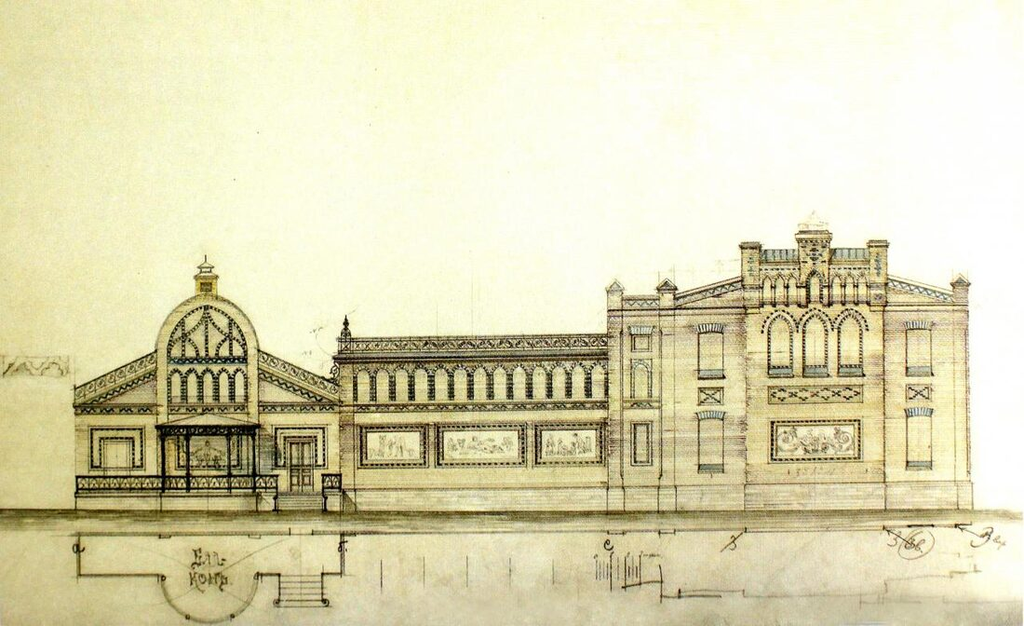

Photo: [Silvio Danini](https://commons.wikimedia.org/wiki/File:A.V.Kozolov_Blueprints.jpg), [public domain](https://creativecommons.org/publicdomain/mark/1.0/), via Wikimedia Commons

## Problem statement and motivation

Why did you write the software? What is special and why others should use it? Why existing tools don’t do the job? Putting your work in the context of existing software.

- JSS
- RJ
- JOSS
- Genome Biology

> What do we do when we analyze data? What are common actions and what are common mistakes? Given the importance of this activity in statistics, there is remarkably little research on how data analysis happens. This paper attempts to remedy a very small part of that lack by describing one common data analysis pattern: Split-apply-combine.

> Since the launch of Sputnik 1 in 1957, the developments in space technology have enabled a fast growth of the amount of satellites placed in orbit around Earth. Such growth has become especially prominent in the last decade, as evidenced by the fact that over a third of the 11,697 satellite launches performed until September 2021 occurred over the last 5 years (United Nations)…

> Planning the launch, operation and orbital maneuvers of satellites requires predictions of the trajectory that a satellite will follow along time from a known state vector (a set of parameters that define the position, velocity and acceleration of the satellite at a given instant)…

> We introduce asteRisk, an R package that aims to provide a suite for astrodynamics analysis in R…

> Satellite remote sensing has become essential for environmental monitoring, agriculture, disastervmanagement, and land use analysis. Modern sensor constellations such as Sentinel-2, Landsat, and PlanetScope produce petabytes of freely available imagery, yet the Python ecosystem for processing this data remains fragmented. A typical analysis workflow requires stitching together multiple libraries: rasterio for I/O, GDAL (GDAL/OGR contributors, 2024) for warping, NumPy (Harris et al., 2020) for array math, xarray for labeled dimensions, geopandas (Jordahl et al., 2020) for vector operations, and scikit-learn for modeling, each with its own conventions for handling coordinate reference systems, nodata values, affine transforms, and chunked computation.

> Precise genomic variant comparison is fundamental to improving sequencing technologies and ensuring accurate variant calling for research and clinical applications. Therefore, it is critical that variant comparison tools, also known as benchmarking tools, provide the best means to identify real differences between variant call sets by minimizing the representation issues that persist across technology platforms and variant calling software. While sequencing technologies have advanced, there has not been much active development on variant benchmarking tools because they require a great deal of care to properly implement and are often viewed as a resource rather than scientific advancement. As technologies improve, the fraction of false positive/negative variants will shift from true addressable errors to benchmarking issues, slowing the pace of technological improvement. This justifies a renewed effort to improve variant comparison tools, as well as the genomic truthsets they rely on.

## Key features of the software

- JSS
- RJ
- JOSS
- Genome Biology

Very clear: Re-organising and summarising data, shown using tables and illustrations.

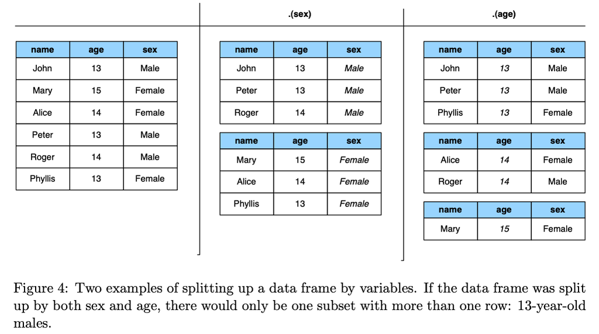

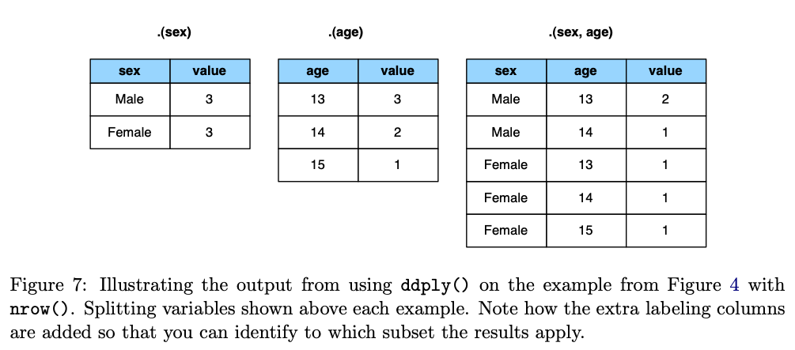

> To that extent, implementations of some of the most frequently applied orbital propagators are provided, including the SGP4 and SDP4 models (Dong and Chang-yin 2010), as well as a high-precision numerical orbital propagator. Additionally, utilities for reading file formats commonly used to distribute satellite positions (ephemeris) are provided.

> The package also provides tools for the calculation of orbital parameters from the coordinates and velocity of a satellite and vice versa, as well as for the conversion of coordinates between different frames of reference.

The sections of the paper match these components.

Note: *Some of the functionalities provided with asteRisk require large data tables. These are provided in the accessory data package asteRiskData, which is distributed through a drat repository and can be installed by running.*

> The library includes built-in sensor profiles for Landsat 1–8, Sentinel-1 and Sentinel-2, MODIS, and NAIP that automate band naming, scaling, and metadata handling.

> It supports workflows spanning cloud-based data access via SpatioTemporal Asset Catalogs (STAC) from multiple providers, a full radiometric processing chain (DN-to-reflectance conversion, atmospheric correction, BRDF normalization, and topographic correction), vegetation index computation, raster-vector interoperability, Cython-accelerated moving window statistics, scikit-learn-based (Pedregosa et al., 2011) machine learning classification, deep learning with PyTorch (Paszke et al., 2019), and georeferenced object detection.

> By leveraging Dask’s lazy evaluation and task graphs, GeoWombat enables out-of-core processing of raster datasets of any size on commodity hardware.

> Aardvark, a variant benchmarking tool that introduces the basepair score to directly compare haplotype sequences, reducing representation biases while allowing for partial credit scoring. The tool also includes the traditional genotype score and supports separate or joint benchmarking of small variants, tandem repeats, and structural variants (<10 kb).

> Aardvark accepts standard inputs, runs 18x faster than hap.py, and is open source

## Design/implementation details

- JSS
- RJ
- JOSS
- Genome Biology

The paper does not have any design and implementation details. It is very user-facing, providing motivation and how to use it. At most, it explains the conceptualisation that makes usage easier:

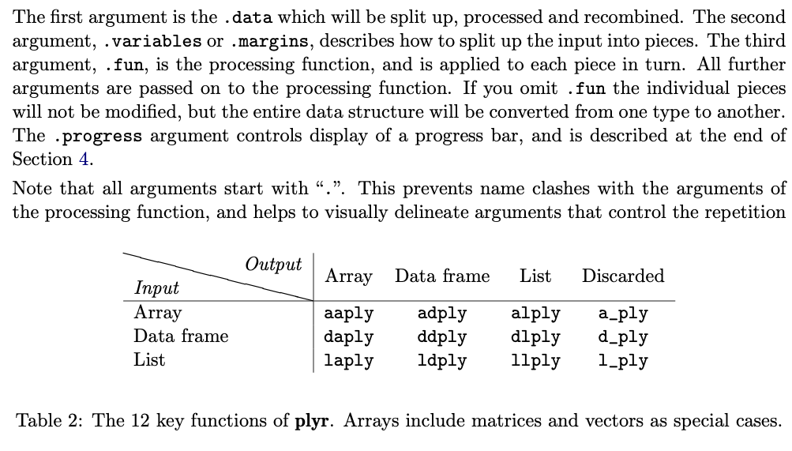

Primarily user facing, with few details on design and implementation.

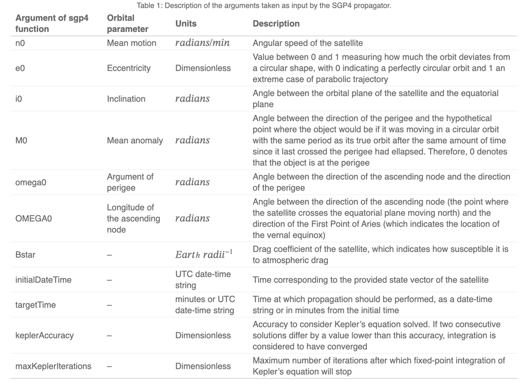

> **Software design**

> GeoWombat’s architecture centers on three design principles:
> 1. lazy evaluation for scalability,
> 2. configuration-driven defaults for usability, > and
> 3. xarray accessor extensibility.

JOSS requires authors to dedicate an main section of the publication on their design

Design and implementation details are in the Methods section (after the Conclusions)

> **Overview**

> Aardvark prioritizes a sequence-centric approach to variant benchmarking. Thus, the core algorithmic problem is to efficiently compare diploid haplotype sequences that are derived from two sets of input variants: “truth” and “query” sets. To take advantage of parallelism, Aardvark first divides the problem space into sub-regions that are solved independently. For each sub-region, Aardvark will 1) construct optimized truth and query haplotype sequence pairs from the provided variants such that the total edit distance between the pairs is minimized, and 2) score the optimization solution using multiple scoring schemes.

## Examples/use cases/applications/speed comparisons/benchmarking

- JSS
- RJ
- JOSS
- Genome Biology

Two worked examples, that illustrate reasonably complex data processing.

Baseball statistics

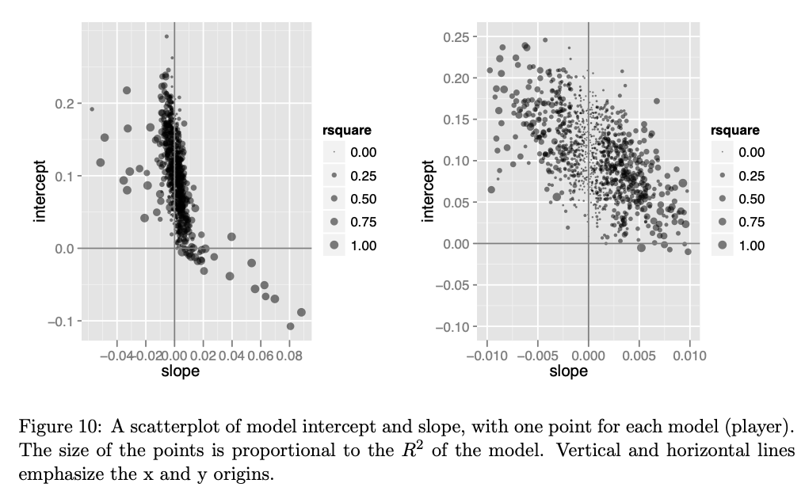

Spatiotemporal patterns in ozone

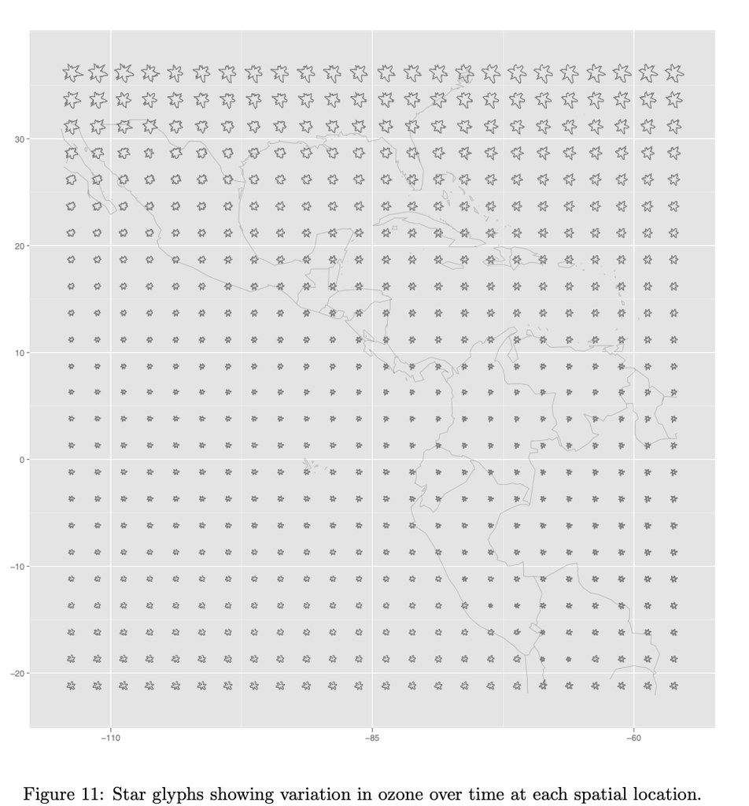

Examples are worked into the explanation of the functionality.

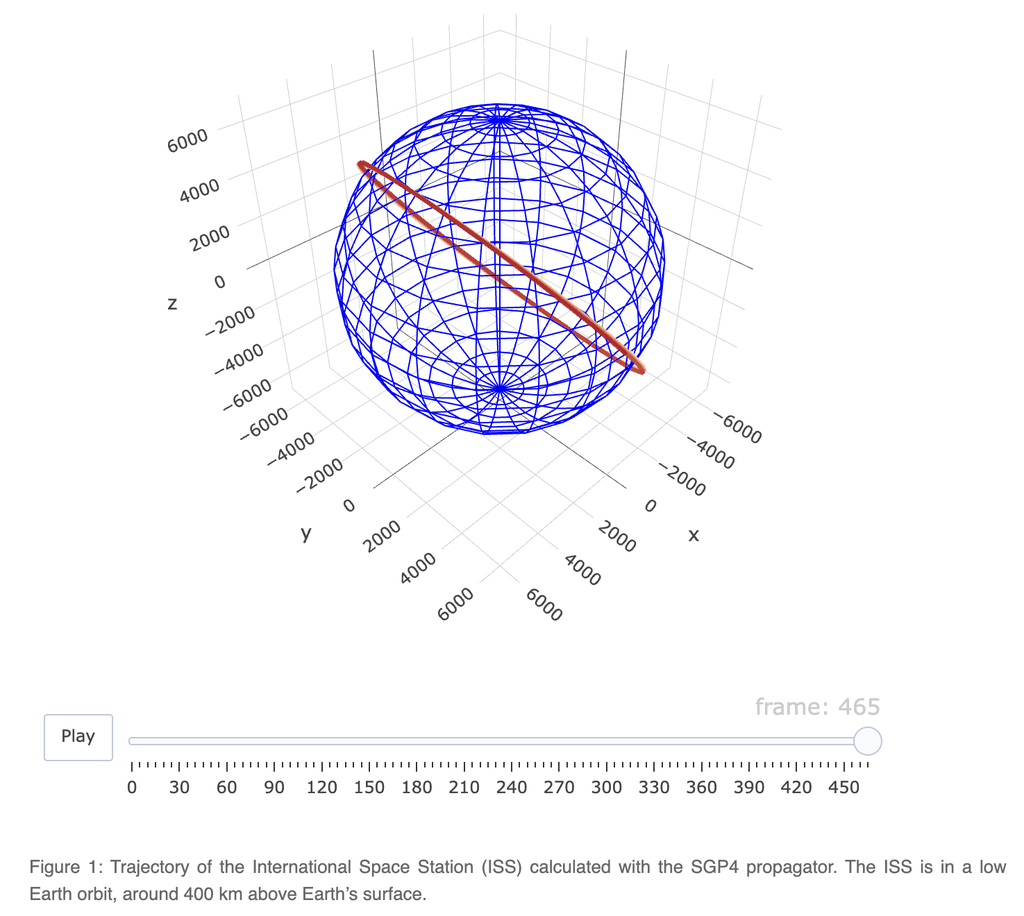

Very minimal illustration of the machine learning pipelines (data source unknown)

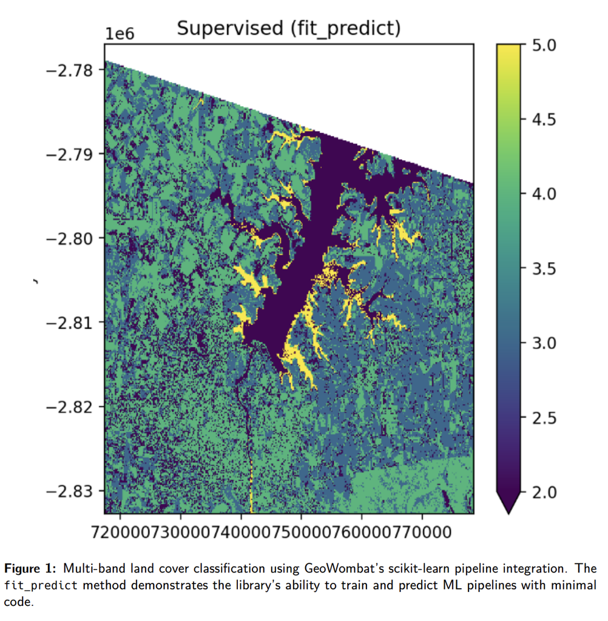

> The library’s documentation includes tutorials covering all major features, and it is installable via pip and conda-forge,

Results section illustrates features of Aardvark while comparing it with current tools

Compare with other tools

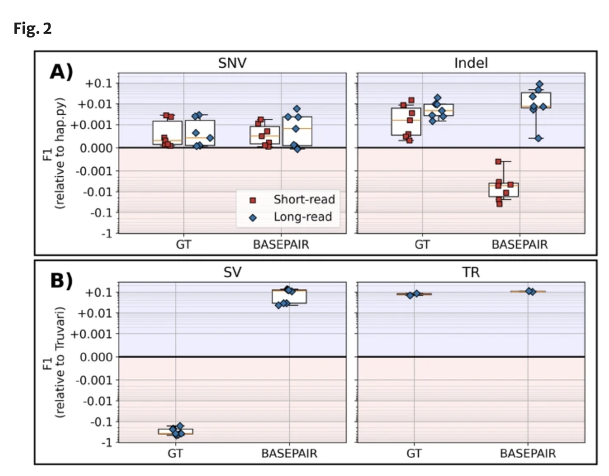

Benchmark comparisons across different data types

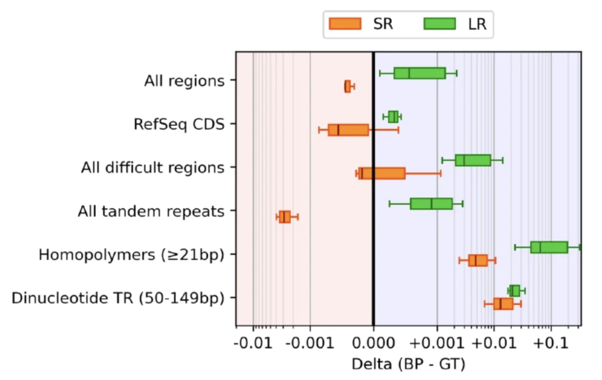

## Your turn

1. Decide on one of your own software projects to turn into a paper
2. Map out key items of the paper, with a couple of sentences on each of these:
   - motivation
   - design and implementation
   - usage
   - application

If you would prefer, you could use [ohwhaley](https://fontikar.github.io/ohwhaley/) or [datasauRus](https://jumpingrivers.github.io/datasauRus/) as your software.

## End of session 1

[figure not shown]

This work is licensed under a [Creative Commons Attribution-NonCommercial-ShareAlike 4.0 International License](http://creativecommons.org/licenses/by-nc-sa/4.0/).